# (Flights Dataset Exploration)

## Preliminary Wrangling

> This dataset reports flights in the United States, including carriers, arrival and departure delays, and reasons for delays, from 2010 to 2020.

```python
# import all packages and set plots to be embedded inline
import numpy as np
import pandas as pd
import matplotlib.pyplot as plt
from matplotlib.colors import to_rgb
import seaborn as sb

%matplotlib inline
```

```python
# load in the dataset into a pandas dataframe, print statistics
df = pd.read_csv('flights dataset.csv')
```

```python
# high-level overview of data shape and composition
print(df.shape)
print(df.dtypes)
```

```
(159766, 22)
year                     int64
 month                   int64
carrier                 object
carrier_name            object
airport                 object
airport_name            object
arr_flights            float64
arr_del15              float64
carrier_ct             float64
 weather_ct            float64
nas_ct                 float64
security_ct            float64
late_aircraft_ct       float64
arr_cancelled          float64
arr_diverted           float64
 arr_delay             float64
 carrier_delay         float64
weather_delay          float64
nas_delay              float64
security_delay         float64
late_aircraft_delay    float64
Unnamed: 21            float64
dtype: object
```

```python
df.head(10)
```

|  | year | month | carrier | carrier_name | airport | airport_name | arr_flights | arr_del15 | carrier_ct | weather_ct | ... | late_aircraft_ct | arr_cancelled | arr_diverted | arr_delay | carrier_delay | weather_delay | nas_delay | security_delay | late_aircraft_delay | Unnamed: 21 |
| --- | --- | --- | --- | --- | --- | --- | --- | --- | --- | --- | --- | --- | --- | --- | --- | --- | --- | --- | --- | --- | --- |
| 0 | 2011 | 12 | DL | Delta Air Lines Inc. | STL | St. Louis, MO: St Louis Lambert International | 396.0 | 34.0 | 13.90 | 0.68 | ... | 12.89 | 0.0 | 0.0 | 1680.0 | 698.0 | 19.0 | 204.0 | 0.0 | 759.0 | NaN |
| 1 | 2011 | 12 | DL | Delta Air Lines Inc. | STT | Charlotte Amalie, VI: Cyril E King | 42.0 | 4.0 | 3.09 | 0.00 | ... | 0.00 | 0.0 | 0.0 | 93.0 | 75.0 | 0.0 | 18.0 | 0.0 | 0.0 | NaN |
| 2 | 2011 | 12 | DL | Delta Air Lines Inc. | STX | Christiansted, VI: Henry E. Rohlsen | 3.0 | 0.0 | 0.00 | 0.00 | ... | 0.00 | 0.0 | 0.0 | 0.0 | 0.0 | 0.0 | 0.0 | 0.0 | 0.0 | NaN |
| 3 | 2011 | 12 | DL | Delta Air Lines Inc. | SYR | Syracuse, NY: Syracuse Hancock International | 55.0 | 5.0 | 2.50 | 0.00 | ... | 1.00 | 0.0 | 1.0 | 147.0 | 80.0 | 0.0 | 35.0 | 0.0 | 32.0 | NaN |
| 4 | 2011 | 12 | DL | Delta Air Lines Inc. | TLH | Tallahassee, FL: Tallahassee International | 31.0 | 5.0 | 1.25 | 0.00 | ... | 2.74 | 0.0 | 0.0 | 332.0 | 92.0 | 0.0 | 39.0 | 0.0 | 201.0 | NaN |
| 5 | 2011 | 12 | DL | Delta Air Lines Inc. | TPA | Tampa, FL: Tampa International | 893.0 | 90.0 | 30.77 | 1.37 | ... | 33.12 | 3.0 | 0.0 | 4434.0 | 1416.0 | 140.0 | 710.0 | 0.0 | 2168.0 | NaN |
| 6 | 2011 | 12 | DL | Delta Air Lines Inc. | TUL | Tulsa, OK: Tulsa International | 28.0 | 3.0 | 1.00 | 0.00 | ... | 0.87 | 0.0 | 0.0 | 98.0 | 29.0 | 0.0 | 22.0 | 0.0 | 47.0 | NaN |
| 7 | 2011 | 12 | DL | Delta Air Lines Inc. | TUS | Tucson, AZ: Tucson International | 89.0 | 18.0 | 4.26 | 0.24 | ... | 6.70 | 0.0 | 1.0 | 646.0 | 259.0 | 15.0 | 153.0 | 0.0 | 219.0 | NaN |
| 8 | 2011 | 12 | DL | Delta Air Lines Inc. | TYS | Knoxville, TN: McGhee Tyson | 28.0 | 6.0 | 1.38 | 0.00 | ... | 3.82 | 0.0 | 0.0 | 191.0 | 43.0 | 0.0 | 21.0 | 0.0 | 127.0 | NaN |
| 9 | 2011 | 12 | DL | Delta Air Lines Inc. | VPS | Valparaiso, FL: Eglin AFB Destin Fort Walton B... | 26.0 | 2.0 | 1.00 | 0.00 | ... | 0.44 | 0.0 | 0.0 | 60.0 | 35.0 | 0.0 | 14.0 | 0.0 | 11.0 | NaN |

10 rows × 22 columns

```python
df.describe()
```

|  | year | month | arr_flights | arr_del15 | carrier_ct | weather_ct | nas_ct | security_ct | late_aircraft_ct | arr_cancelled | arr_diverted | arr_delay | carrier_delay | weather_delay | nas_delay | security_delay | late_aircraft_delay | Unnamed: 21 |
| --- | --- | --- | --- | --- | --- | --- | --- | --- | --- | --- | --- | --- | --- | --- | --- | --- | --- | --- |
| count | 159766.00000 | 159766.000000 | 159531.000000 | 159335.000000 | 159531.000000 | 159531.000000 | 159531.000000 | 159531.000000 | 159531.000000 | 159531.000000 | 159531.000000 | 159531.000000 | 159531.000000 | 159531.000000 | 159531.000000 | 159531.000000 | 159531.000000 | 0.0 |
| mean | 2015.63747 | 6.527353 | 385.477149 | 69.258104 | 19.932764 | 2.145940 | 21.490234 | 0.131169 | 25.472960 | 7.574791 | 0.896390 | 4187.800753 | 1307.208311 | 198.302336 | 1000.302048 | 5.735381 | 1676.248271 | NaN |
| std | 3.04247 | 3.470750 | 1030.703698 | 182.280781 | 44.974315 | 6.718006 | 66.755794 | 0.578655 | 74.978867 | 44.032246 | 3.839979 | 12054.194308 | 3550.021730 | 718.364020 | 3668.976284 | 31.703741 | 5041.782538 | NaN |
| min | 2010.00000 | 1.000000 | 1.000000 | 0.000000 | 0.000000 | 0.000000 | 0.000000 | 0.000000 | 0.000000 | 0.000000 | 0.000000 | 0.000000 | 0.000000 | 0.000000 | 0.000000 | 0.000000 | 0.000000 | NaN |
| 25% | 2013.00000 | 3.000000 | 55.000000 | 7.000000 | 2.450000 | 0.000000 | 1.400000 | 0.000000 | 1.710000 | 0.000000 | 0.000000 | 368.000000 | 121.000000 | 0.000000 | 47.000000 | 0.000000 | 85.000000 | NaN |
| 50% | 2016.00000 | 7.000000 | 115.000000 | 20.000000 | 6.950000 | 0.360000 | 4.700000 | 0.000000 | 5.900000 | 1.000000 | 0.000000 | 1088.000000 | 393.000000 | 17.000000 | 173.000000 | 0.000000 | 366.000000 | NaN |
| 75% | 2018.00000 | 10.000000 | 274.000000 | 51.000000 | 17.890000 | 1.800000 | 13.490000 | 0.000000 | 16.990000 | 4.000000 | 1.000000 | 2990.000000 | 1092.000000 | 137.000000 | 536.000000 | 0.000000 | 1138.000000 | NaN |
| max | 2020.00000 | 12.000000 | 21977.000000 | 5268.000000 | 1242.160000 | 295.280000 | 2401.790000 | 26.070000 | 1849.000000 | 4951.000000 | 256.000000 | 429194.000000 | 196944.000000 | 31960.000000 | 137443.000000 | 3194.000000 | 148181.000000 | NaN |

```python
df.info()
```

```
<class 'pandas.core.frame.DataFrame'>
RangeIndex: 159766 entries, 0 to 159765
Data columns (total 22 columns):
 #   Column               Non-Null Count   Dtype
---  ------               --------------   -----
 0   year                 159766 non-null  int64
 1    month               159766 non-null  int64
 2   carrier              159766 non-null  object
 3   carrier_name         159766 non-null  object
 4   airport              159766 non-null  object
 5   airport_name         159766 non-null  object
 6   arr_flights          159531 non-null  float64
 7   arr_del15            159335 non-null  float64
 8   carrier_ct           159531 non-null  float64
 9    weather_ct          159531 non-null  float64
 10  nas_ct               159531 non-null  float64
 11  security_ct          159531 non-null  float64
 12  late_aircraft_ct     159531 non-null  float64
 13  arr_cancelled        159531 non-null  float64
 14  arr_diverted         159531 non-null  float64
 15   arr_delay           159531 non-null  float64
 16   carrier_delay       159531 non-null  float64
 17  weather_delay        159531 non-null  float64
 18  nas_delay            159531 non-null  float64
 19  security_delay       159531 non-null  float64
 20  late_aircraft_delay  159531 non-null  float64
 21  Unnamed: 21          0 non-null       float64
dtypes: float64(16), int64(2), object(4)
memory usage: 26.8+ MB
```

### The data need some simple cleaning

```python
# drop the last column and drop the nan values
df = df.iloc[:, :-1]
df.dropna()
```

|  | year | month | carrier | carrier_name | airport | airport_name | arr_flights | arr_del15 | carrier_ct | weather_ct | ... | security_ct | late_aircraft_ct | arr_cancelled | arr_diverted | arr_delay | carrier_delay | weather_delay | nas_delay | security_delay | late_aircraft_delay |
| --- | --- | --- | --- | --- | --- | --- | --- | --- | --- | --- | --- | --- | --- | --- | --- | --- | --- | --- | --- | --- | --- |
| 0 | 2011 | 12 | DL | Delta Air Lines Inc. | STL | St. Louis, MO: St Louis Lambert International | 396.0 | 34.0 | 13.90 | 0.68 | ... | 0.0 | 12.89 | 0.0 | 0.0 | 1680.0 | 698.0 | 19.0 | 204.0 | 0.0 | 759.0 |
| 1 | 2011 | 12 | DL | Delta Air Lines Inc. | STT | Charlotte Amalie, VI: Cyril E King | 42.0 | 4.0 | 3.09 | 0.00 | ... | 0.0 | 0.00 | 0.0 | 0.0 | 93.0 | 75.0 | 0.0 | 18.0 | 0.0 | 0.0 |
| 2 | 2011 | 12 | DL | Delta Air Lines Inc. | STX | Christiansted, VI: Henry E. Rohlsen | 3.0 | 0.0 | 0.00 | 0.00 | ... | 0.0 | 0.00 | 0.0 | 0.0 | 0.0 | 0.0 | 0.0 | 0.0 | 0.0 | 0.0 |
| 3 | 2011 | 12 | DL | Delta Air Lines Inc. | SYR | Syracuse, NY: Syracuse Hancock International | 55.0 | 5.0 | 2.50 | 0.00 | ... | 0.0 | 1.00 | 0.0 | 1.0 | 147.0 | 80.0 | 0.0 | 35.0 | 0.0 | 32.0 |
| 4 | 2011 | 12 | DL | Delta Air Lines Inc. | TLH | Tallahassee, FL: Tallahassee International | 31.0 | 5.0 | 1.25 | 0.00 | ... | 0.0 | 2.74 | 0.0 | 0.0 | 332.0 | 92.0 | 0.0 | 39.0 | 0.0 | 201.0 |
| ... | ... | ... | ... | ... | ... | ... | ... | ... | ... | ... | ... | ... | ... | ... | ... | ... | ... | ... | ... | ... | ... |
| 159761 | 2019 | 1 | MQ | Envoy Air | RIC | Richmond, VA: Richmond International | 195.0 | 68.0 | 12.12 | 1.87 | ... | 0.0 | 36.04 | 22.0 | 0.0 | 4138.0 | 603.0 | 196.0 | 780.0 | 0.0 | 2559.0 |
| 159762 | 2019 | 1 | MQ | Envoy Air | ROA | Roanoke, VA: Roanoke Blacksburg Regional Woodr... | 52.0 | 14.0 | 2.74 | 0.69 | ... | 0.0 | 8.11 | 2.0 | 1.0 | 726.0 | 323.0 | 31.0 | 112.0 | 0.0 | 260.0 |
| 159763 | 2019 | 1 | MQ | Envoy Air | ROC | Rochester, NY: Greater Rochester International | 106.0 | 26.0 | 4.67 | 2.26 | ... | 0.0 | 7.26 | 17.0 | 0.0 | 1259.0 | 313.0 | 99.0 | 484.0 | 0.0 | 363.0 |
| 159764 | 2019 | 1 | MQ | Envoy Air | RST | Rochester, MN: Rochester International | 116.0 | 35.0 | 6.83 | 6.92 | ... | 0.0 | 9.75 | 22.0 | 0.0 | 2307.0 | 474.0 | 633.0 | 523.0 | 0.0 | 677.0 |
| 159765 | 2019 | 1 | MQ | Envoy Air | SAT | San Antonio, TX: San Antonio International | 26.0 | 4.0 | 1.16 | 0.64 | ... | 0.0 | 0.29 | 5.0 | 0.0 | 120.0 | 50.0 | 14.0 | 41.0 | 0.0 | 15.0 |

159335 rows × 21 columns

```python
# remove space from columns names
df.columns = df.columns.str.lstrip()
```

```python
df.columns
```

```
Index(['year', 'month', 'carrier', 'carrier_name', 'airport', 'airport_name',
       'arr_flights', 'arr_del15', 'carrier_ct', 'weather_ct', 'nas_ct',
       'security_ct', 'late_aircraft_ct', 'arr_cancelled', 'arr_diverted',
       'arr_delay', 'carrier_delay', 'weather_delay', 'nas_delay',
       'security_delay', 'late_aircraft_delay'],
      dtype='object')
```

### What is the structure of your dataset?

> There are 159335 flights information in the dataset with each entry lists the number of flights, the number of flights delayed, the number of flights canceled and diverted, the minutes of delay due to (carrier-weather-national air system-security) and finally the sum of total delay minutes.

### What is/are the main feature(s) of interest in your dataset?

> I'm most interested in figuring out what features are best for predicting the flight being delayed, canceled or diverted.

### What features in the dataset do you think will help support your investigation into your feature(s) of interest?

> I expect that carrier will have the strongest effect on the numbers of flights. I also think that the other time data will have effects on the numbers.

## Univariate Exploration

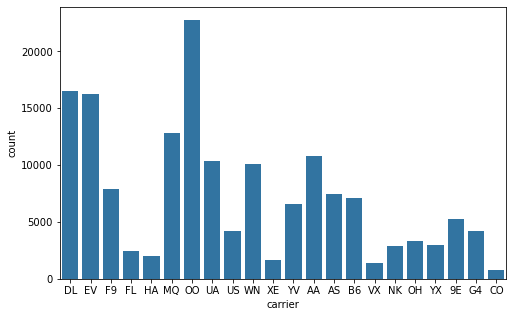

```python
# plot the casrrier qualitative variable to get an idea of its distribution.
default_color = sb.color_palette()[0]
plt.figure(figsize=[8, 5])
sb.countplot(data = df, x = 'carrier', color = default_color);
```

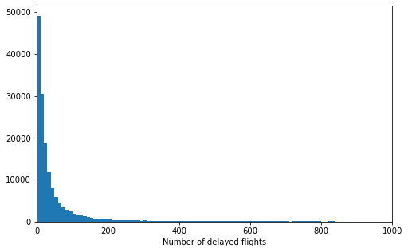

```python
# start with a standard-scaled plot for the number of delayed flights
binsize = 10
bins = np.arange(0, df.arr_del15.max()+binsize, binsize)

plt.figure(figsize=[8, 5])
plt.hist(df.arr_del15, bins = bins)
plt.xlim(0,1000)
plt.xlabel('Number of delayed flights');
```

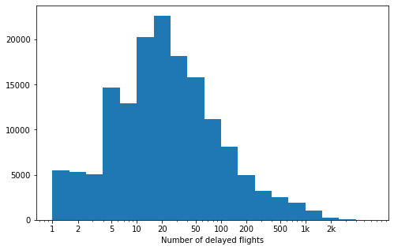

```python
# let's put it on a log scale instead
log_binsize = 0.2
bins = 10 ** np.arange(0, np.log10(df.arr_del15.max())+log_binsize, log_binsize)

plt.figure(figsize=[8, 5])
plt.hist(df.arr_del15, bins = bins)
plt.xscale('log')
plt.xticks([1, 2, 5, 10, 20, 50, 100, 200, 500, 1000, 2000], [1, 2, 5, 10, 20, 50, 100, 200, 500, '1k', '2k'])
plt.xlabel('Number of delayed flights');
```

number of delayed flights has a long-tailed distribution, with a lot of numbers on the low section end, and few on the high section end. When plotted on a log-scale, the distribution looks roughly unimodal, with one peak a little above 20.

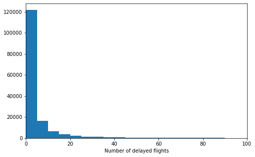

```python
# start with a standard-scaled plot for the number of canceled flights
binsize = 5
bins = np.arange(0, df.arr_cancelled.max()+binsize, binsize)

plt.figure(figsize=[8, 5])
plt.hist(df.arr_cancelled, bins = bins)
plt.xlim(0,100)
plt.xlabel('Number of delayed flights');
```

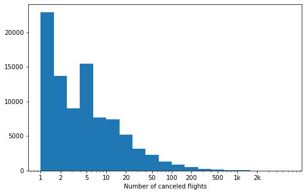

```python
# let's try the same approach for the number of canceled flights
log_binsize = 0.2
bins = 10 ** np.arange(0, np.log10(df.arr_cancelled.max())+log_binsize, log_binsize)

plt.figure(figsize=[8, 5])
plt.hist(df.arr_cancelled, bins = bins)
plt.xscale('log')
plt.xticks([1, 2, 5, 10, 20, 50, 100, 200, 500, 1000, 2000], [1, 2, 5, 10, 20, 50, 100, 200, 500, '1k', '2k'])
plt.xlabel('Number of canceled flights');
```

number of canceled flights has a long-tailed distribution, with a lot of numbers on the low section end, and few on the high section end the same as the number of delayed flights. When plotted on a log-scale, the distribution looks roughly bimodal, right-skewed with one peak a little above 1 and another above 5.

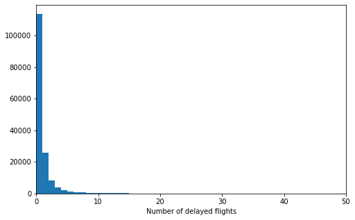

```python
# start with a standard-scaled plot for the number of diverted flights
binsize = 1
bins = np.arange(0, df.arr_diverted.max()+binsize, binsize)

plt.figure(figsize=[8, 5])
plt.hist(df.arr_diverted, bins = bins)
plt.xlim(0,50)
plt.xlabel('Number of delayed flights');
```

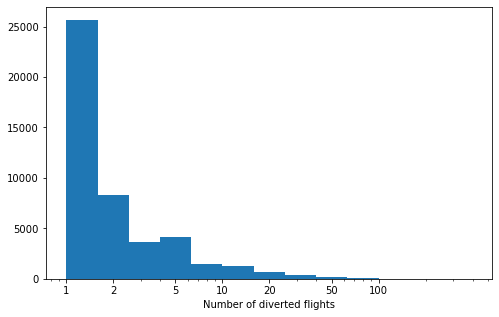

```python
# again with the same approach for the number of diverted flights
log_binsize = 0.2
bins = 10 ** np.arange(0, np.log10(df.arr_diverted.max())+log_binsize, log_binsize)

plt.figure(figsize=[8, 5])
plt.hist(df.arr_diverted, bins = bins)
plt.xscale('log')
plt.xticks([1, 2, 5, 10, 20, 50, 100], [1, 2, 5, 10, 20, 50, 100])
plt.xlabel('Number of diverted flights');
```

the same as before but the number of diverted flights distribution on the log scale is still roughly skewed to the right

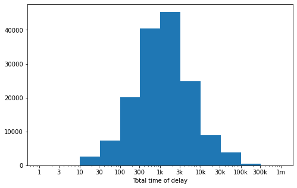

```python
# now let's see the total delay distribution
log_binsize = 0.5
bins = 10 ** np.arange(0, np.log10(df.arr_delay.max())+log_binsize, log_binsize)

plt.figure(figsize=[8, 5])
plt.hist(df.arr_delay, bins = bins)
plt.xscale('log')
plt.xticks([1, 3, 10, 30, 100, 300, 1000, 3e3, 1e4, 3e4, 1e5, 3e5, 1e6], [1, 3, 10, 30, 100, 300, '1k', '3k', '10k', '30k', '100k', '300k', '1m'])
plt.xlabel('Total time of delay');
```

Interestingly the distribution of the total time of delay on the log scale has a normal distribution shape with a mean around 1k.

### Discuss the distribution(s) of your variable(s) of interest. Were there any unusual points? Did you need to perform any transformations?

> I needed to preforme a log transformation to see the distribution more clearly.

### Of the features you investigated, were there any unusual distributions? Did you perform any operations on the data to tidy, adjust, or change the form of the data? If so, why did you do this?

> no.

## Bivariate Exploration

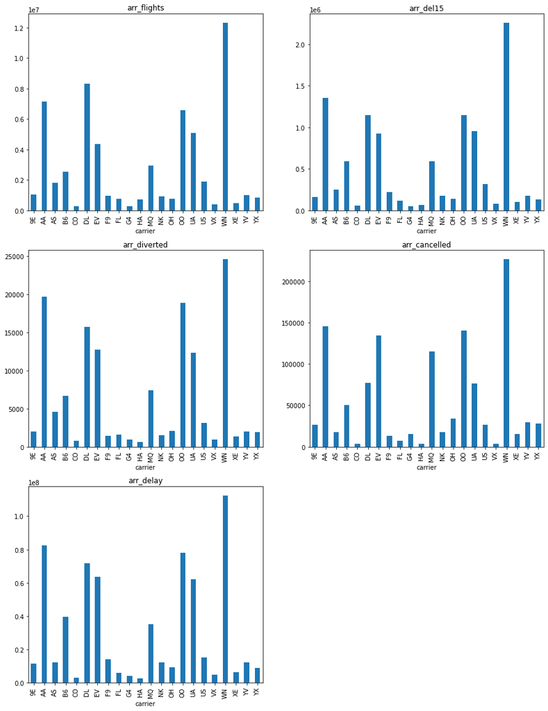

```python
# Let's see the distributions again but after grouping by the carrier
count_columns = ['arr_flights','arr_del15','arr_diverted', 'arr_cancelled', 'arr_delay']
fig, ax = plt.subplots(ncols = 2, nrows = 3 , figsize = [15,20])
axe = ax.ravel()
axe[5].axis('off')

for idx, column in enumerate(count_columns):
    df.groupby('carrier')[column].sum().plot(kind='bar', title=column, ax=axe[idx]);
```

It seems that Southwest Airlines Co. carrier (WN) really stands out in every case which requires feature engineering to really see the distribution.

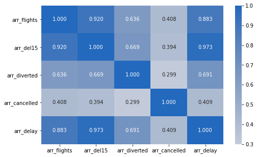

```python
# let's now see the correlation between the different numbers of flights and the total delay time
plt.figure(figsize = [8, 5])
sb.heatmap(df[count_columns].corr(), annot = True, fmt = '.3f', cmap = 'vlag_r', center = 0);
```

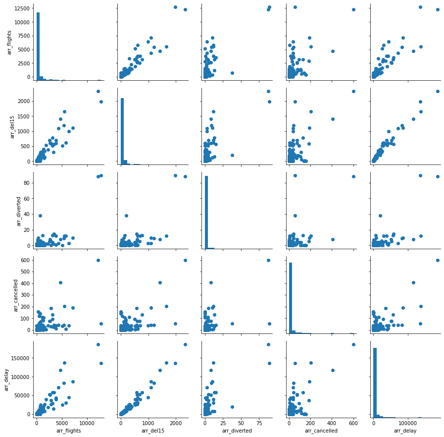

```python
# plot matrix: sample 500 flights
samples = np.random.choice(df.shape[0], 500, replace = False)
df_samp = df.loc[samples,:]

g = sb.PairGrid(data = df_samp, vars = count_columns)
g = g.map_diag(plt.hist, bins = 20);
g.map_offdiag(plt.scatter);
```

As expected, there are two strong correlations stands out between the total time of delay and the number of delayed flights also between the the number delayed flights and the number of arrived flights.

Next I'm gonna look deeper in the reasons of delay:

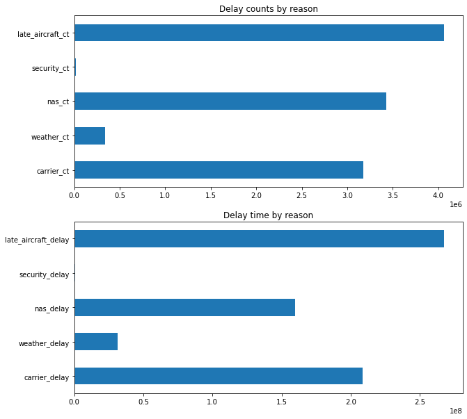

```python
delay_counts = ['carrier_ct', 'weather_ct', 'nas_ct', 'security_ct', 'late_aircraft_ct']
delay_time = ['carrier_delay', 'weather_delay', 'nas_delay', 'security_delay', 'late_aircraft_delay']
fig, ax = plt.subplots(nrows = 2 , figsize = [10,10])

(df[delay_counts].sum()).plot(kind='barh', title='Delay counts by reason', ax=ax[0])
(df[delay_time].sum()).plot(kind='barh', title='Delay time by reason', ax=ax[1]);
```

It's clear to see that the late aircraft reason has the hightest numbers while the security reason has the lowest in both counts and time terms.

### Talk about some of the relationships you observed in this part of the investigation. How did the feature(s) of interest vary with other features in the dataset?

> All the features distributions with the carrier seem to have the same shape while the delay reasons have a clear distribution.

### Did you observe any interesting relationships between the other features (not the main feature(s) of interest)?

> The features are related to the total number of flights for each carrier not just the carrier itself which can be seen better with feature engineering also for the delay reasons.

## Multivariate Exploration

```python
# make a color palette for the carriers
carriers = list(df.carrier.unique())
carriers.sort()
color = sb.color_palette('tab20c')
color.extend([to_rgb('#b33939'), to_rgb('#ff5252')])
colours = {carriers[i]: color[i] for i in range(len(carriers))}
```

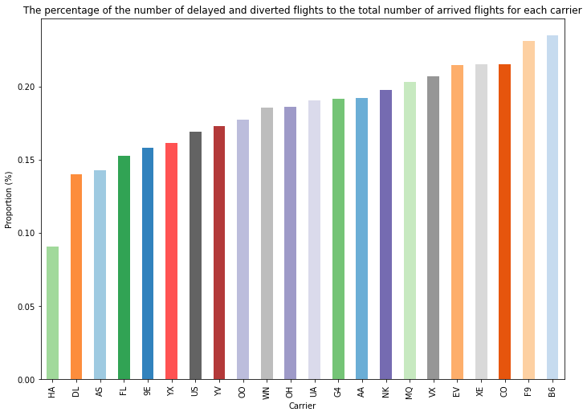

```python
# The percentage of the number of delayed and diverted flights to the total number of arrived flights for each carrier visual
plt.figure(figsize=[11.69, 8.27])
s1 = ((df.groupby('carrier').arr_del15.sum() + df.groupby('carrier').arr_diverted.sum()) / df.groupby('carrier').arr_flights.sum()).sort_values()
s1.plot(kind='bar', color=s1.index.map(colours))
plt.title('The percentage of the number of delayed and diverted flights to the total number of arrived flights for each carrier')
plt.xlabel('Carrier')
plt.ylabel('Proportion (%)');
```

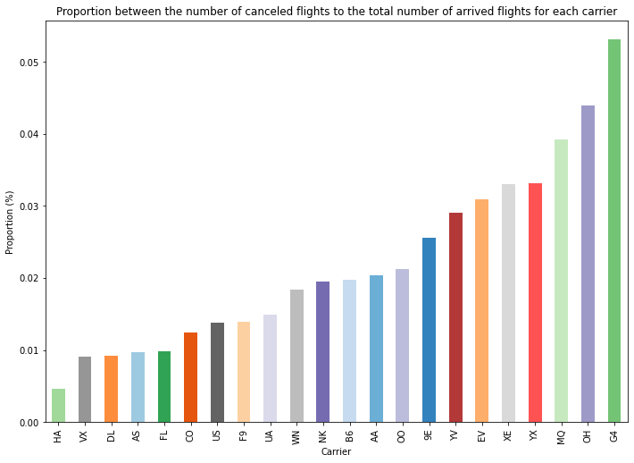

```python
# Proportion between the number of canceled flights to the total number of arrived flights for each carrier visual
plt.figure(figsize=[11.69, 8.27])
s2 = (df.groupby('carrier').arr_cancelled.sum() / df.groupby('carrier').arr_flights.sum()).sort_values()
s2.plot(kind='bar', color=s2.index.map(colours))
plt.title('Proportion between the number of canceled flights to the total number of arrived flights for each carrier')
plt.xlabel('Carrier')
plt.ylabel('Proportion (%)');
```

At the end the result shows that the JetBlue Airways carrier (B6) has the highest proportion of delayed and diverted flights, the Allegiant Air carrier (G4) has the hightest proportions in canceled flights and Hawaiian Airlines Inc. carrier has the lowest proportions in all.

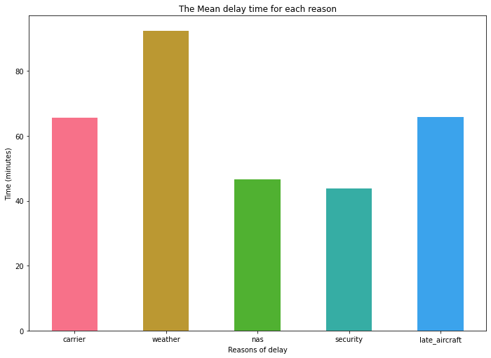

```python
# Proportion between the total time of delay to the counts of delayed flights for each reason
reasons_names = ['carrier', 'weather', 'nas', 'security', 'late_aircraft']
# change the two series indexes name to match
a = df[delay_time].sum()
reasons = {a.index[i]: reasons_names[i] for i in range(len(reasons_names))}
a.rename(index=reasons, inplace=True)

b = df[delay_counts].sum()
reasons = {b.index[i]: reasons_names[i] for i in range(len(reasons_names))}
b.rename(index=reasons, inplace=True)
# plot the visual
plt.figure(figsize=[11.69, 8.27])
(np.divide(a, b)).plot(kind='bar', color=sb.color_palette("husl"), rot=0)
plt.title('The Mean delay time for each reason')
plt.xlabel('Reasons of delay')
plt.ylabel('Time (minutes)');
```

Interestingly, the weather has the highest mean not the late aircraft like we expected from the visuals before.

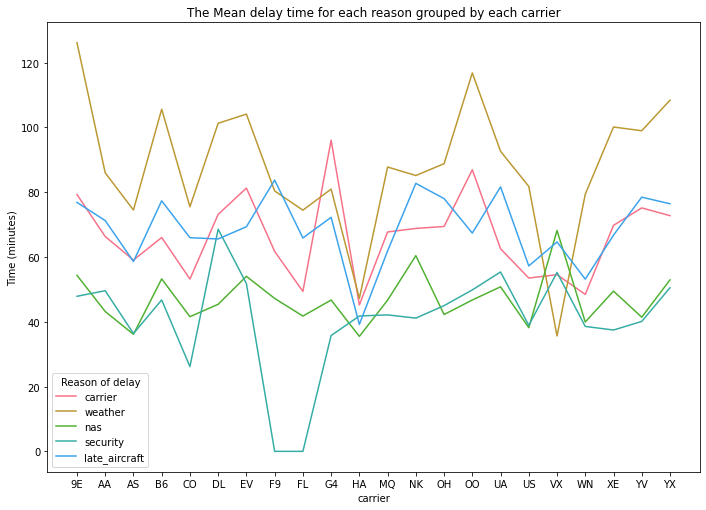

```python
# Proportion between the total time of delay to the counts of delayed flights for each reason grouped by each carrier
reasons_names = ['carrier', 'weather', 'nas', 'security', 'late_aircraft']
# change the two dataframes columns name to match
a = df.groupby('carrier')[delay_time].sum()
reasons = {a.columns[i]: reasons_names[i] for i in range(len(reasons_names))}
a.rename(columns=reasons, inplace=True)

b = df.groupby('carrier')[delay_counts].sum()
reasons = {b.columns[i]: reasons_names[i] for i in range(len(reasons_names))}
b.rename(columns=reasons, inplace=True)
# plot the visual
ax = (a.div(b).fillna(0)).plot(figsize=[11.69, 8.27], color=sb.color_palette("husl"))
ax.set_xticks(np.arange(0, 22, 1))
ax.set_xticklabels(a.index)
plt.legend(title='Reason of delay')
plt.ylabel('Time (minutes)')
plt.title('The Mean delay time for each reason grouped by each carrier');
```

### Talk about some of the relationships you observed in this part of the investigation. Were there features that strengthened each other in terms of looking at your feature(s) of interest?

> Indeed the number of arrived flights for each carrier changed the pattern seen before so did the comapring the mean delay time for each reason.

### Were there any interesting or surprising interactions between features?

> Southwest Airlines Co. carrier (WN) doesn't stand out anymore and late aircraft doesn't have the hightest mean of delay time.